# Hard Work 3 Part 2

### Problem 3.16 {6}{ 6/6 }

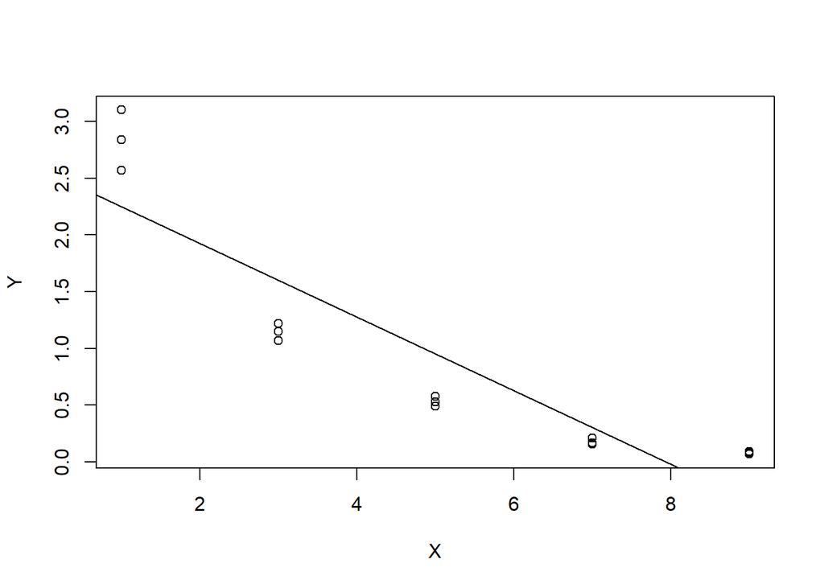

```r
# Load the Data:
p3.15 <- read.table("http://www.stat.ufl.edu/~rrandles/sta4210/Rclassnotes/data/textdatasets/KutnerData/Chapter%20%203%20Data%20Sets/CH03PR15.txt")

# Rewrite the column names to be "Y" and "X" to match the textbook:
colnames(p3.15) <- c("Y","X")
p3.15.lm <- lm(Y ~ X, data = p3.15)

plot(Y~X, data = p3.15)
abline(p3.15.lm)
```

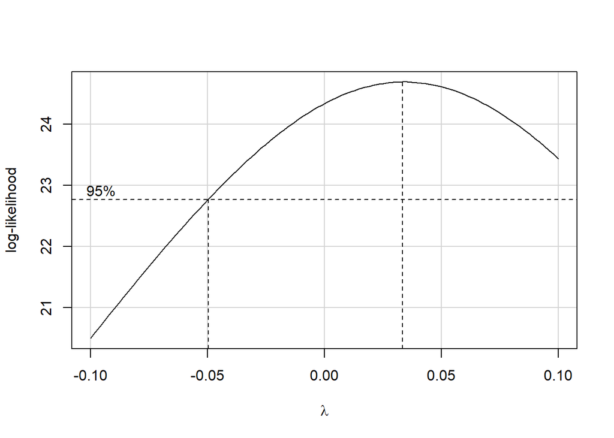

```r
boxCox(p3.15.lm, lambda = seq(-0.1,0.1, 0.01))
```

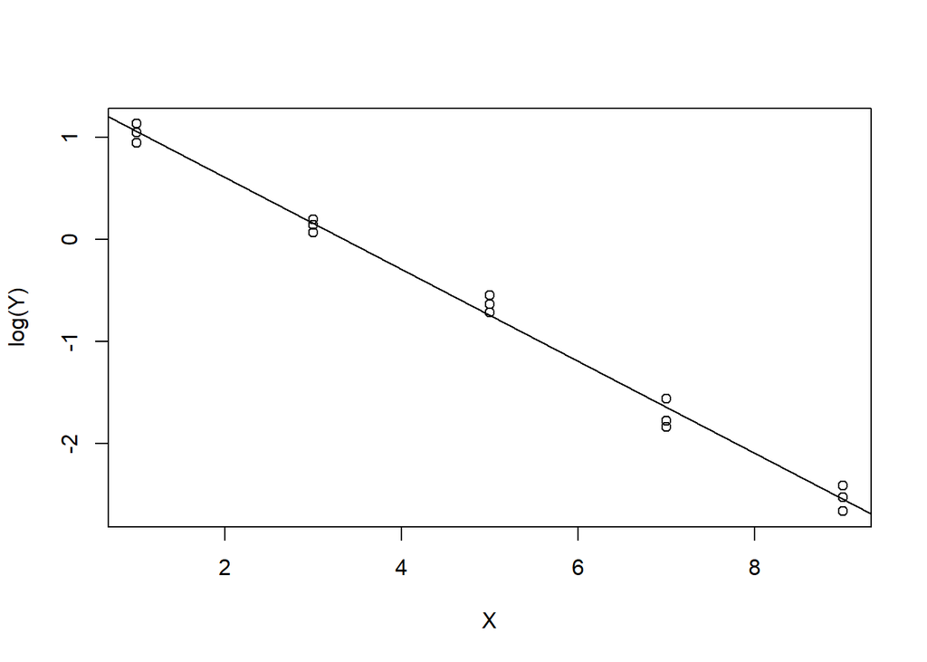

```r
#We plot the regression in our faux universe
plot(log(Y) ~ X, data = p3.15)
p3.15.lm.log <- lm(log(Y) ~ X, data = p3.15)
abline(p3.15.lm.log)
```

```r
#We pull out our values for this regression...
summary(p3.15.lm.log)
```

```
##
## Call:
## lm(formula = log(Y) ~ X, data = p3.15)
##
## Residuals:
##      Min       1Q   Median       3Q      Max
## -0.19102 -0.10228  0.01569  0.07716  0.19699
##
## Coefficients:
##             Estimate Std. Error t value Pr(>|t|)
## (Intercept)  1.50792    0.06028   25.01 2.22e-12 ***
## X           -0.44993    0.01049  -42.88 2.19e-15 ***
## ---
## Signif. codes:  0 '***' 0.001 '**' 0.01 '*' 0.05 '.' 0.1 ' ' 1
##
## Residual standard error: 0.115 on 13 degrees of freedom
## Multiple R-squared:  0.993,  Adjusted R-squared:  0.9924
## F-statistic:  1838 on 1 and 13 DF,  p-value: 2.188e-15
```

```r
#And plot them into the real world.
plot(Y ~ X, data  = p3.15)
b <- coef(p3.15.lm.log)
b
```

```
## (Intercept)           X
##   1.5079164  -0.4499258
```

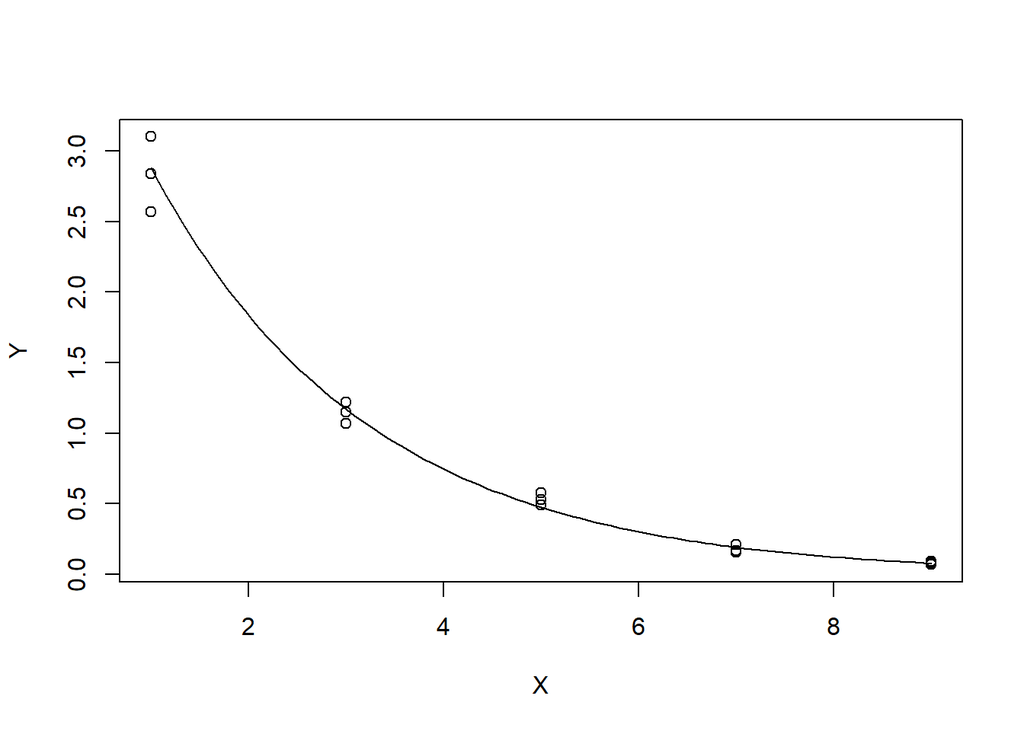

```r
curve(exp(b[1] + b[2]*x), add = TRUE)
```

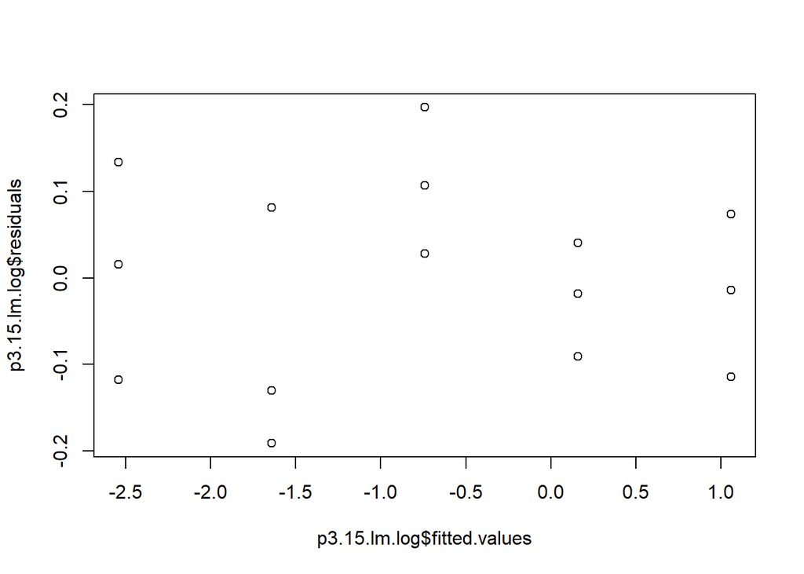

```r
plot(p3.15.lm.log$residuals ~ p3.15.lm.log$fitted.values)
```

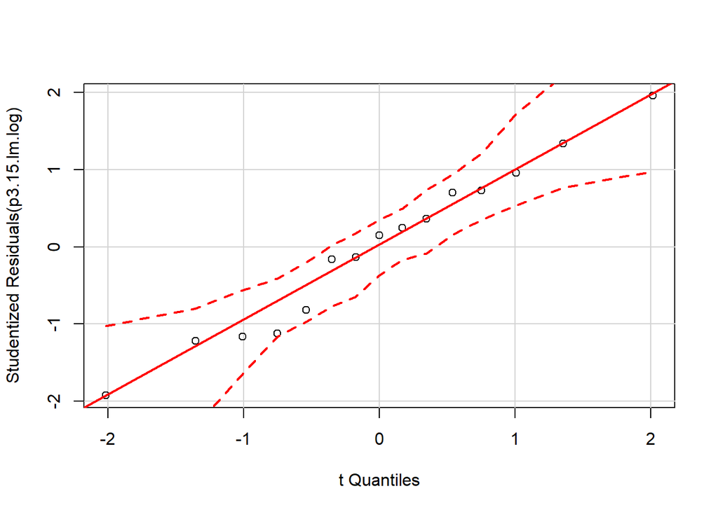

```r
qqPlot(p3.15.lm.log)
```

1. Because this plot slopes down exponentially and the variance continually gets smaller, I would use a Y transformation fo Yprime = 1/y.
2. It looks like 0 is recommended according to our BoxCox test. Which means that we are going to use log(y).
3. log(y) = y` = b0 + b1*x
4. This line works a lot better. It is a good fit.
5. There is constant variance and normality for the transformed data.
6. y = e^(b0+b1*x)

### Problem 3.17 {6}{ 6/6 }

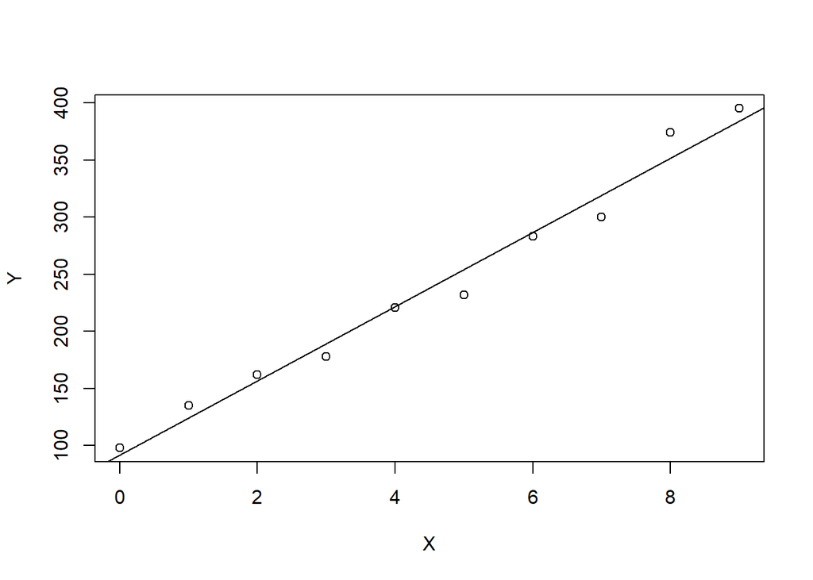

```r
# Load the Data:
p3.17 <- read.table("http://www.stat.ufl.edu/~rrandles/sta4210/Rclassnotes/data/textdatasets/KutnerData/Chapter%20%203%20Data%20Sets/CH03PR17.txt")

# Rewrite the column names to be "Y" and "X" to match the textbook:
colnames(p3.17) <- c("Y","X")

p3.17.lm <- lm(Y ~ X, data = p3.17)

plot(Y~X, data = p3.17)

abline(p3.17.lm)
```

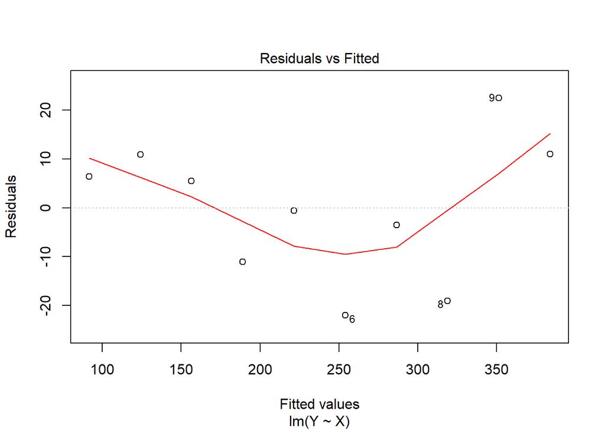

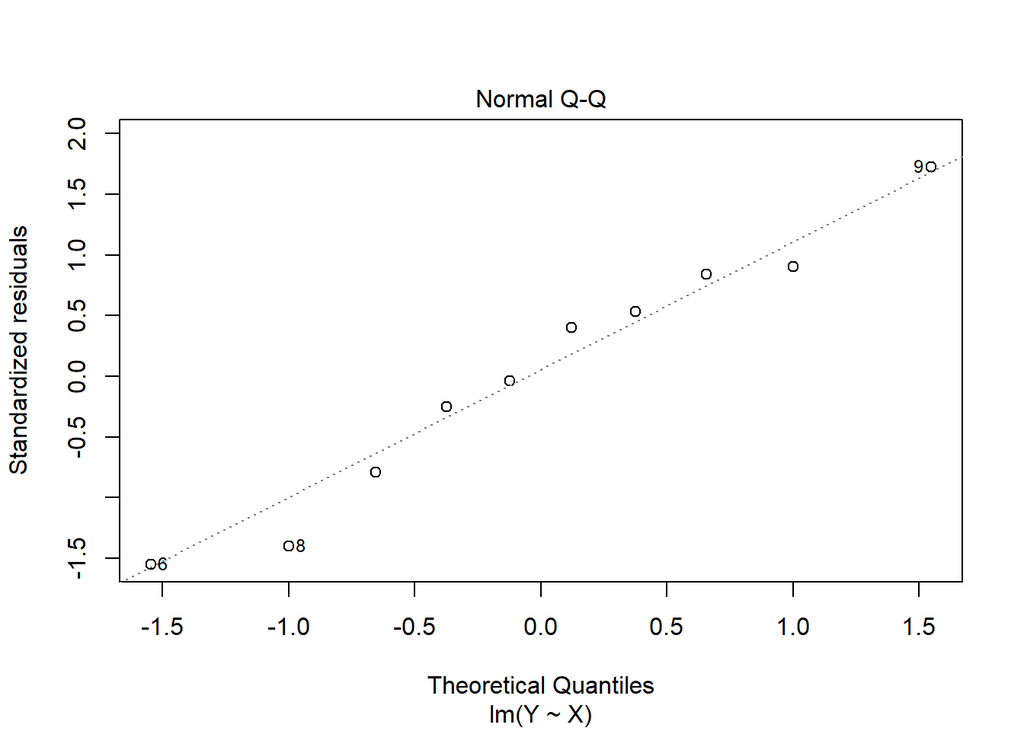

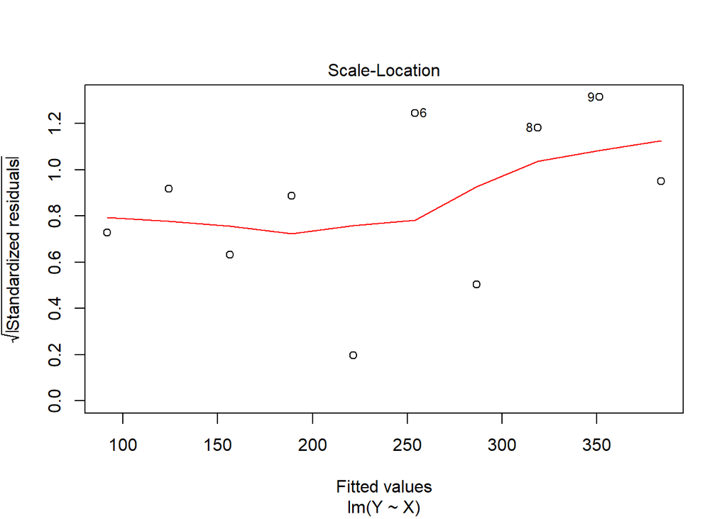

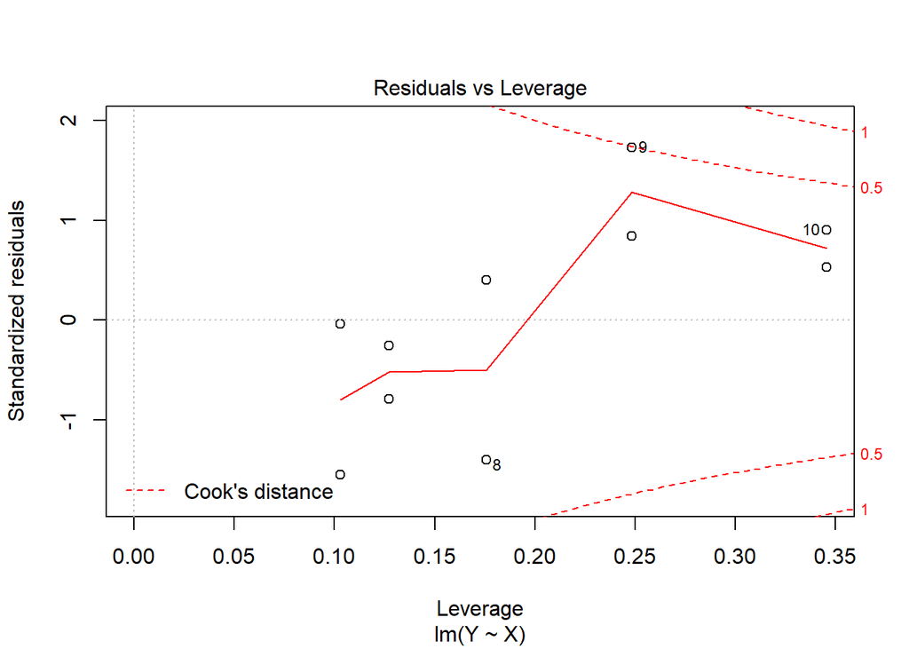

```r
plot(p3.17.lm)
```

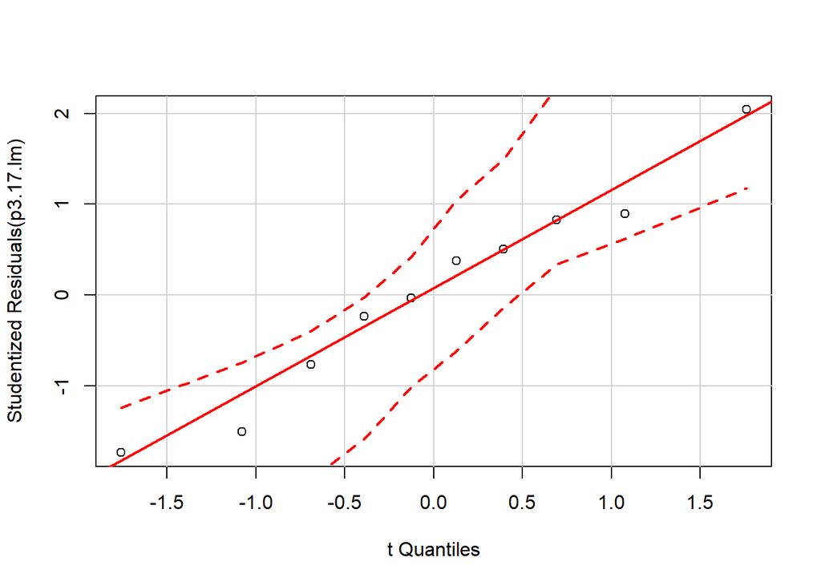

```r
qqPlot(p3.17.lm)
```

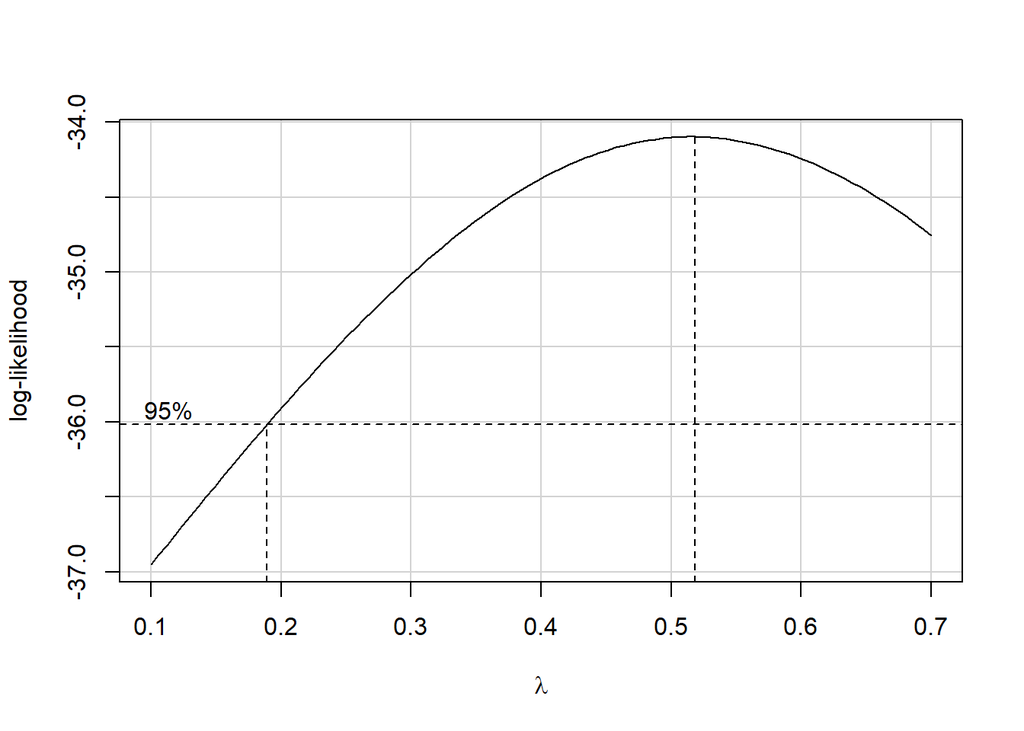

```r
boxCox(p3.17.lm, lambda = seq(0.1, 0.75, 0.1))
```

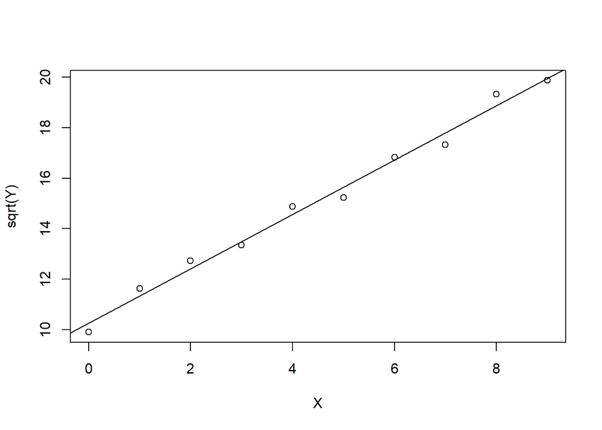

```r
plot(sqrt(Y) ~ X, data = p3.17)

p3.17.lm.sqrt <- lm(sqrt(Y) ~ X, data = p3.17)
abline(p3.17.lm.sqrt)
```

```r
b2 <- coef(p3.17.lm.sqrt)
b2
```

```
## (Intercept)           X
##   10.260931    1.076292
```

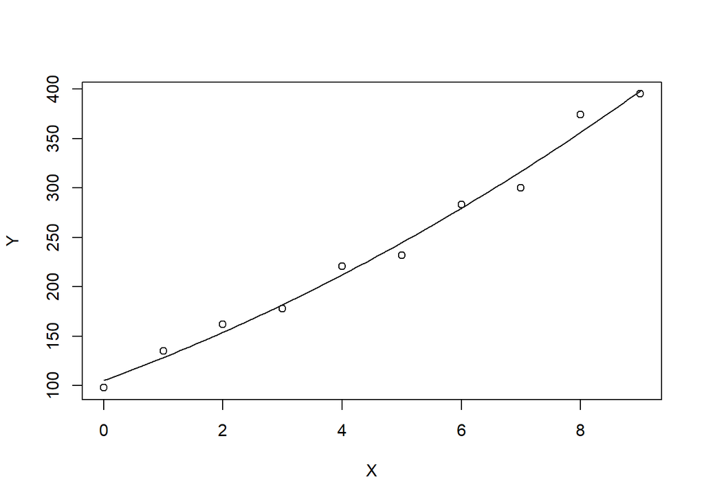

```r
plot(Y ~X , data = p3.17)

curve(((b2[1] + b2[2]*x)^2), add = TRUE)
```

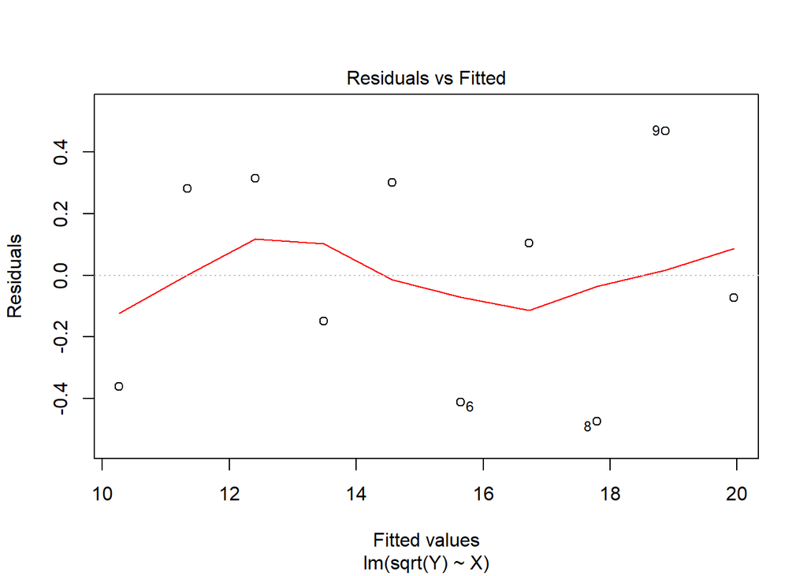

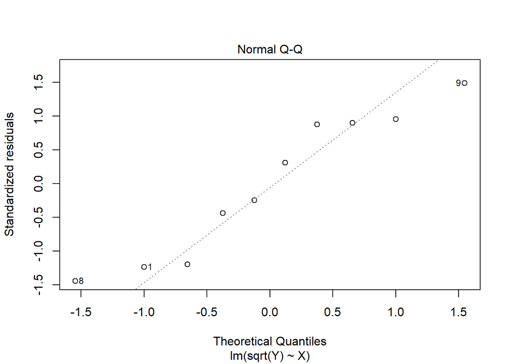

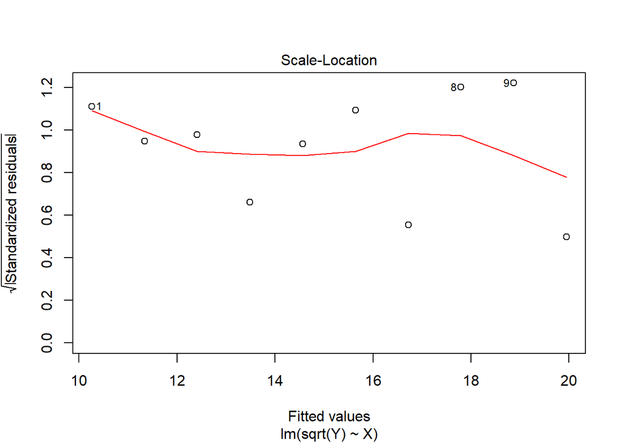

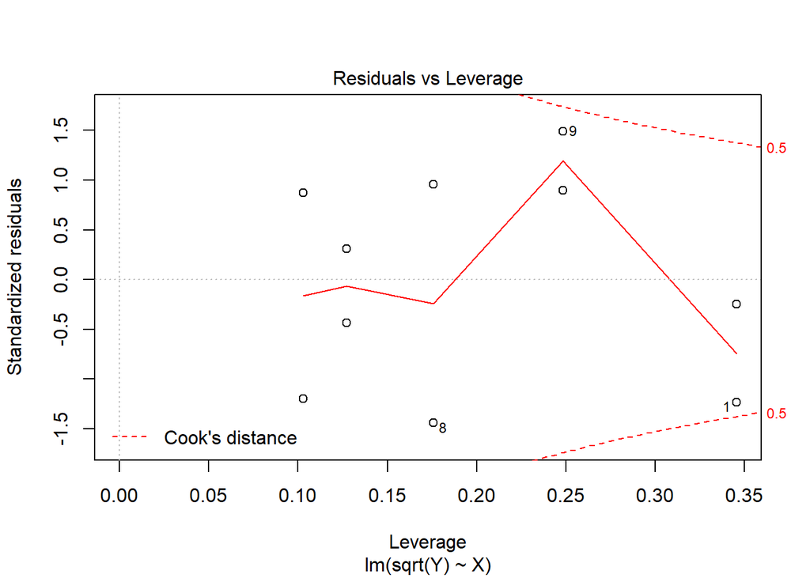

```r
plot(p3.17.lm.sqrt)
```

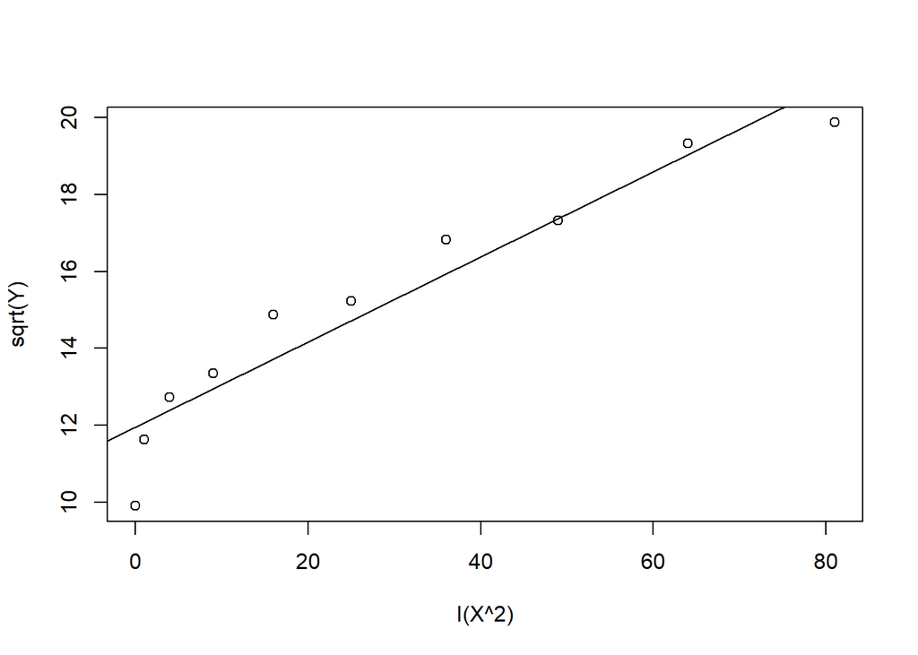

```r
p3.17.x.lm <- lm(sqrt(Y) ~ X, data = p3.17)

plot(sqrt(Y) ~ I(X^2)^2, data = p3.17)

p3.17.x.lm <- lm(sqrt(Y) ~ I(X^2)^2, data = p3.17)
abline(p3.17.x.lm)
```

```r
b3 <- coef(p3.17.x.lm)

b3
```

```
## (Intercept)      I(X^2)
##   11.948495    0.110728
```

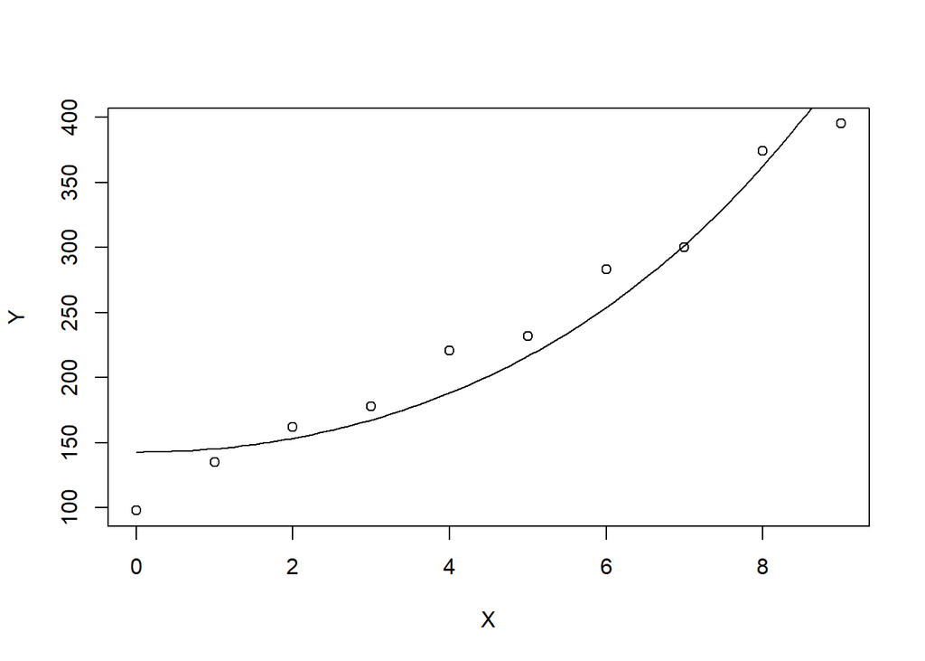

```r
plot(Y~X, data = p3.17)

curve((b3[1] + b3[2]*x^2)^2, add = TRUE)
```

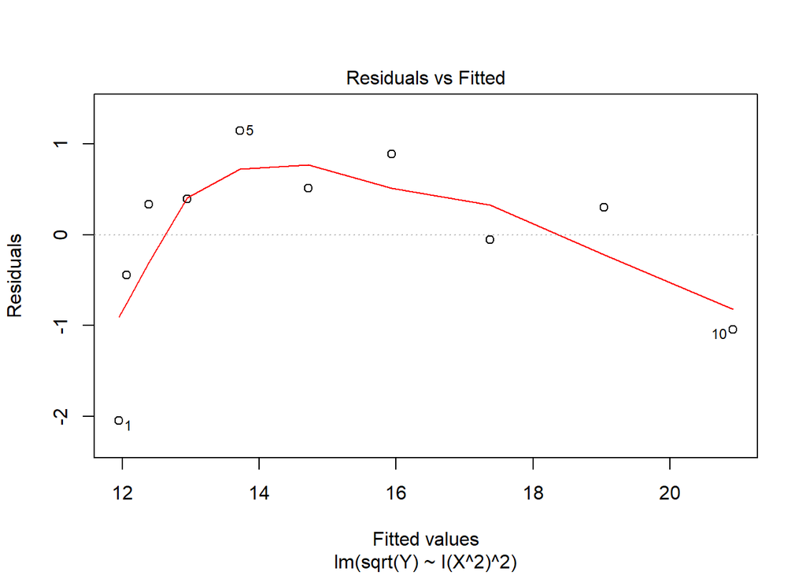

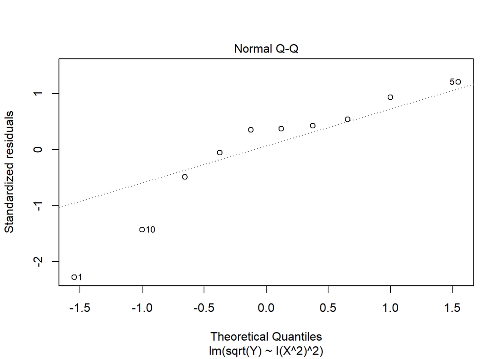

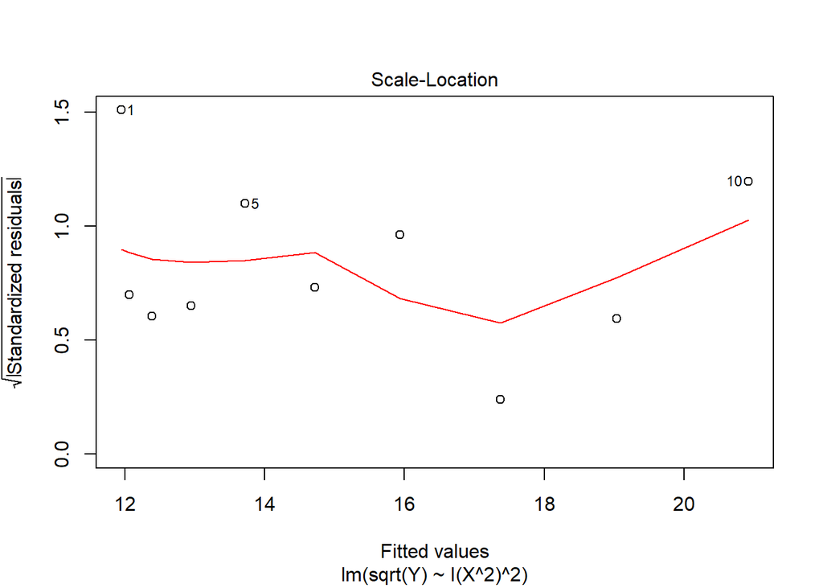

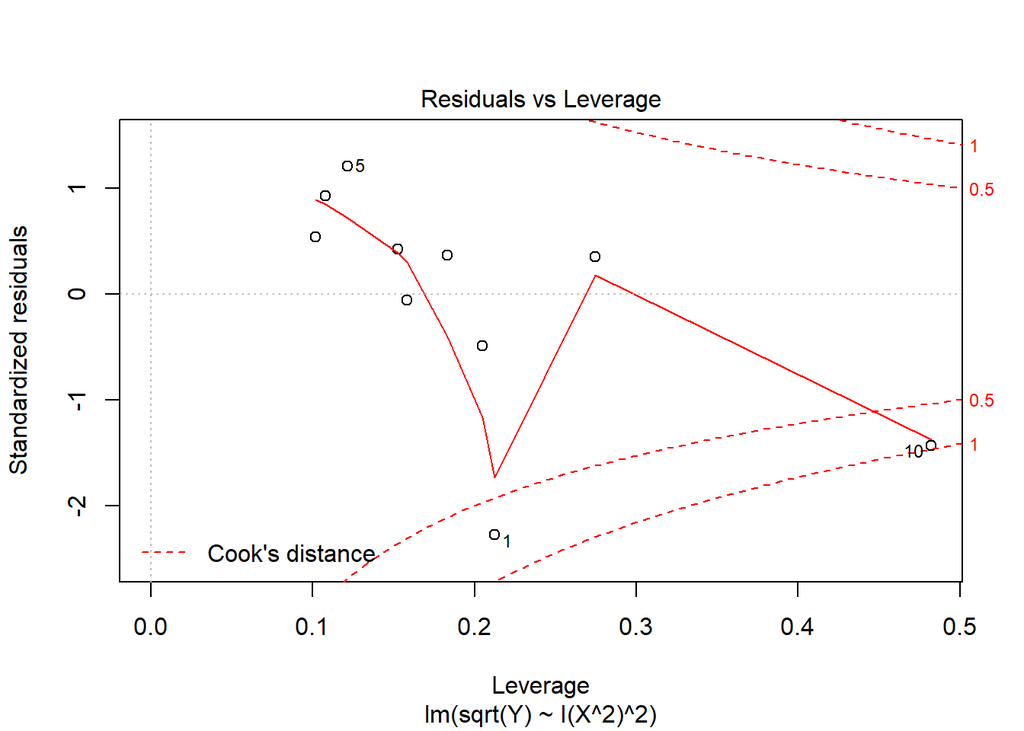

```r
plot(p3.17.x.lm)
```